# Homework 4

## 3.)

The samples come from three different regions of Italy. The regions are further partitioned into nine areas: areas 1â“4 belong to region R1, areas 5 and 6 belong to region R2, and areas 7â“9 belong to region R3. The first column of the file provides the indicator for the nine regions. We will now focus on Region R2. Answer the following questions:

**(a)** Calculate the covariance matrix for the chemical composition in each of the two sub-regions. Display the covariance matrices for the two sub-regions side-by-side, and comment on possible differences. You can use the heatmap to visualize the two matrices. Be sure to use the same scale for the color.

```r
#read in data
olive <- read.table("olive.dat", header=T)
#focus on region 2
olive <- olive %>% filter(group.id %in% c(5,6))
#####
##a
#get covariance matrices
s.5 <- olive %>% filter(group.id ==5) %>% select(-group.id) %>% var
s.6 <- olive %>% filter(group.id ==6) %>% select(-group.id) %>% var
s.5
```

```
##             X1          X2           X3           X4           X5
## X1 1320.640865 -135.234856  -87.1538462 -575.5516827 -495.9939904
## X2 -135.234856  214.625962   25.1514423  -41.4278846   56.7223558
## X3  -87.153846   25.151442  115.2115385 -120.4699519   32.0600962
## X4 -575.551683  -41.427885 -120.4699519 2058.5961538 -587.7295673
## X5 -495.993990   56.722356   32.0600962 -587.7295673 1104.7596154
## X6   32.814423   12.589904  -20.0901442   43.4146635  -61.4675481
## X7  -14.482452   19.871154  -40.9026442   81.6334135  -37.7800481
## X8   -2.883654    1.470433   -0.3365385    0.4543269    0.8461538
##             X6          X7         X8
## X1  32.8144231 -14.4824519 -2.8836538
## X2  12.5899038  19.8711538  1.4704327
## X3 -20.0901442 -40.9026442 -0.3365385
## X4  43.4146635  81.6334135  0.4543269
## X5 -61.4675481 -37.7800481  0.8461538
## X6  29.2966346  31.9372596 -0.4129808
## X7  31.9372596 166.8591346 -0.3504808
## X8  -0.4129808  -0.3504808  0.5615385
```

```r
s.6
```

```
##               X1           X2          X3          X4           X5
## X1  1189.2784091   45.5823864   45.846591 -2000.83523   625.573864
## X2    45.5823864  123.3712121   68.823864  -150.64299   -84.642045
## X3    45.8465909   68.8238636  228.903409  -308.66477    -9.198864
## X4 -2000.8352273 -150.6429924 -308.664773  5267.04735 -2472.440341
## X5   625.5738636  -84.6420455   -9.198864 -2472.44034  1848.767045
## X6    -0.8920455   -1.8910985  -20.920455    38.04072   -27.150568
## X7   110.0681818   13.8143939   20.838068  -421.72538   222.352273
## X8    10.3352273   -0.3049242    2.196023   -19.40152     7.252841
##             X6          X7          X8
## X1  -0.8920455  110.068182  10.3352273
## X2  -1.8910985   13.814394  -0.3049242
## X3 -20.9204545   20.838068   2.1960227
## X4  38.0407197 -421.725379 -19.4015152
## X5 -27.1505682  222.352273   7.2528409
## X6  12.0018939    2.148674   0.1259470
## X7   2.1486742   92.030303   1.7149621
## X8   0.1259470    1.714962   0.5473485
```

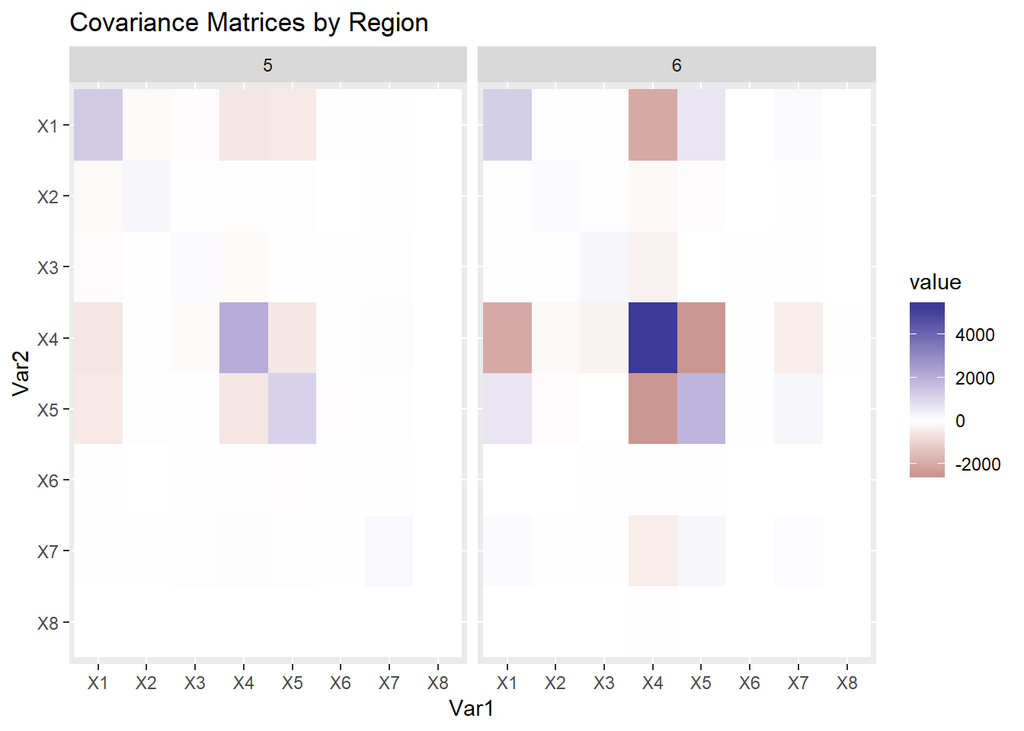

```r
#and also correlation matrices
s.5c <- olive %>% filter(group.id ==5) %>% select(-group.id) %>% cor
s.6c <- olive %>% filter(group.id ==6) %>% select(-group.id) %>% cor

#reformat the data for ggplot
s.5.m <- s.5 %>% melt %>% mutate(id = 5)
s.6.m <- s.6 %>% melt %>% mutate(id = 6)
covdf <- rbind(s.5.m, s.6.m)
s.5.cm <- s.5c %>% melt %>% mutate(id = 5)
s.6.cm <- s.6c %>% melt %>% mutate(id = 6)
covdfc <- rbind(s.5.cm, s.6.cm)

#limits for the color scale
mx <- max(s.5,s.6); mn <- min(s.5,s.6); mid <- median(c(s.5,s.6))
mxc <- max(s.5c,s.6c); mnc <- min(s.5c,s.6c); midc <- median(c(s.5c,s.6c))

#covariance matrix visualized
ggplot(data=covdf, aes(x=Var1, y=Var2, fill=value)) +
  geom_tile() + scale_fill_gradient2(limits=c(mn, mx), midpoint=mid) +
  facet_wrap(~as.factor(id)) + ggtitle("Covariance Matrices by Region") +
  scale_y_discrete(limits = rev(levels(covdf$Var2)))
```

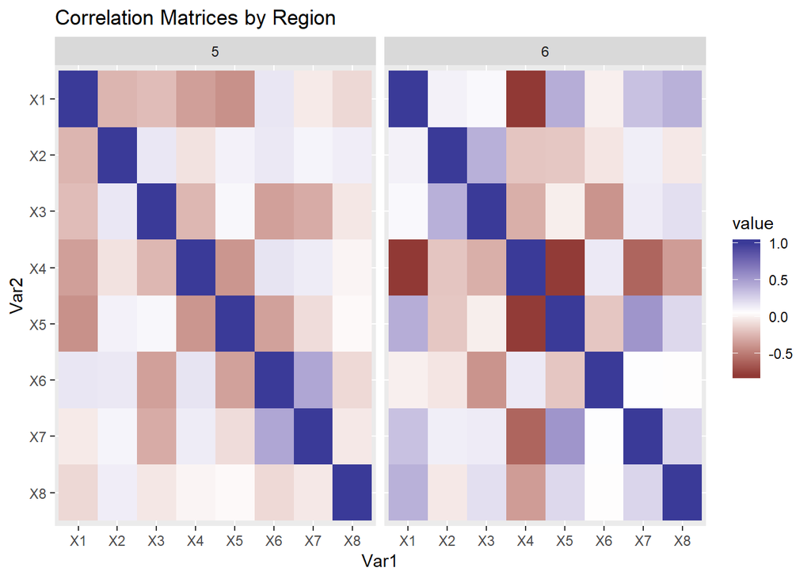

```r
#correlation matrices instead
ggplot(data=covdfc, aes(x=Var1, y=Var2, fill=value)) +
  geom_tile() + facet_wrap(~as.factor(id)) +
  scale_fill_gradient2(limits=c(mnc, mxc), midpoint=midc) + ggtitle("Correlation Matrices by Region") +
  scale_y_discrete(limits = rev(levels(covdfc$Var2)))
```

**(b)** Test for equality of the mean chemical compositions between the two groups. Specifically, report the Hotelling’s $T^{2}$ statistics and its p-value. Are you comfortable to use Hotellingsâ $T^{2}$ test without testing for the multivariate normality of the data and the equivalence of the two covariance matrices?

```r
#split into subregions
olive.x <- olive %>% filter(group.id ==5) %>% select(-group.id)
olive.y <- olive %>% filter(group.id ==6) %>% select(-group.id)
#test for normality first
set.seed(112358)
mvnorm.etest(olive.x, R=10000)
```

```
##
##  Energy test of multivariate normality: estimated parameters
##
## data:  x, sample size 65, dimension 8, replicates 10000
## E-statistic = 1.8342, p-value < 2.2e-16
```

```r
mvnorm.etest(olive.y, R=10000)
```

```
##
##  Energy test of multivariate normality: estimated parameters
##
## data:  x, sample size 33, dimension 8, replicates 10000
## E-statistic = 1.6498, p-value = 6e-04
```

```r
#Get estimated covariance matrices
Sx <- var(olive.x[,5:6])
Sy <- var(olive.y[,5:6])
#are the covariance matrices equal?
Sx; Sy
```

```
##            X5        X6
## X5 1104.75962 -61.46755
## X6  -61.46755  29.29663
```

```
##            X5        X6
## X5 1848.76705 -27.15057
## X6  -27.15057  12.00189
```

```r
#test for equality of means
HotellingsT2(X=olive.x, Y=olive.y)
```

```
##
##  Hotelling's two sample T2-test
##
## data:  olive.x and olive.y
## T.2 = 112.41, df1 = 8, df2 = 89, p-value < 2.2e-16
## alternative hypothesis: true location difference is not equal to c(0,0,0,0,0,0,0,0)
```

We can use the energy test to check for multivariate normality of the data. From the test, we can see that the test rejects the null hypothesis and thus we would conclude that the data are not multivariate normal for either region. However, sample size is large enough that we *might* be able to ignore that. The covariance matrices are obviously not perfectly equal, however if we use the rule of thumb in the lecture notes about individual variances being 4x the element in the other covariance matrix, we see that they are not too different. We can proceed under the assumption that they are the same.

I used the built in Hotelling Test function to conduct the test. The result is a test statistic of 112.41 with a corresponding p-value that is essentially 0, indicating that we should reject the null hypothesis and conclude that the mean vectors of chemical compositions are not equal across regions.

**(c)** Restrict attention to the coordinates for the fifth and sixth chemicals. Provide individual pairwise t-tests for the differences in the composition of the two chemicals among the two groups, using Bonferroni method to adjust the 5% level of significance. Plot their Bonferroni adjusted confidence intervals, and on the same plot, draw the 95% confidence ellipses for the two groups.

See the plot below for visualization. We can see that neither the individual or simultaneous confidence interval contains (0,0), thus we would conclude at $\alpha=.05$ significance level that the mean vectors are not equal across regions, agreeing with the result in (b). The t-tests provide the same result. Note that we use the Bonferroni correction, which just means we divide the significance level by p=2.

```r
#chemical 5
xbarf<- mean(olive.x[,5])-mean(olive.y[,5])
spoolf <- ((length(olive.x[,5])-1)*var(olive.x[,5]) + (length(olive.y[,5])-1)*var(olive.y[,5]))/
  (length(olive.x[,5])+length(olive.y[,5]) - 2)
sef <- sqrt(spoolf)*sqrt(1/length(olive.x[,5]) + 1/length(olive.y[,5]))
dff <- length(olive.x[,5]) + length(olive.y[,5]) - 2

#chemical 6
xbars<- mean(olive.x[,6])-mean(olive.y[,6])
spools <- ((length(olive.x[,6])-1)*var(olive.x[,6]) + (length(olive.y[,6])-1)*var(olive.y[,6]))/
  (length(olive.x[,6])+length(olive.y[,6]) - 2)
ses <- sqrt(spools)*sqrt(1/length(olive.x[,6]) + 1/length(olive.y[,6]))
dfs <- length(olive.x[,6]) + length(olive.y[,6]) - 2


#t-tests with Bonferroni correction
t.test(x=olive.x[,5],y=olive.y[,5], alternative='two.sided', mu=0, conf.level = (1-.05/2), var.equal=T)
```

```
##
##  Two Sample t-test
##
## data:  olive.x[, 5] and olive.y[, 5]
## t = -26.991, df = 96, p-value < 2.2e-16
## alternative hypothesis: true difference in means is not equal to 0
## 97.5 percent confidence interval:
##  -230.0974 -194.2942
## sample estimates:
## mean of x mean of y
##  1125.077  1337.273
```

```r
t.test(x=olive.x[,6],y=olive.y[,6], alternative='two.sided', mu=0, conf.level = (1-.05/2), var.equal=T)
```

```
##
##  Two Sample t-test
##
## data:  olive.x[, 6] and olive.y[, 6]
## t = 4.8483, df = 96, p-value = 4.793e-06
## alternative hypothesis: true difference in means is not equal to 0
## 97.5 percent confidence interval:
##  2.665971 7.388108
## sample estimates:
## mean of x mean of y
##  28.78462  23.75758
```

```r
#Individual CIs with Bonferroni correction:
lbf <- xbarf - qt(1-.05/(2*2), dff) * sef
ubf <- xbarf + qt(1-.05/(2*2), dff) * sef
lbf<- round(lbf,3); ubf <- round(ubf,3)
lbs <- xbars - qt(1-.05/(2*2), dfs) * ses
ubs <- xbars + qt(1-.05/(2*2), dfs) * ses
lbs<- round(lbs,3); ubs <- round(ubs,3)
paste("chemical 5: (", lbf, " , ", ubf, ")", sep="")
```

```
## [1] "chemical 5: (-230.097 , -194.294)"
```

```r
paste("chemical 6: (", lbs, " , ", ubs, ")", sep="")
```

```
## [1] "chemical 6: (2.666 , 7.388)"
```

```r
#get pooled covariance matrix
lx <- nrow(olive.x); ly<-nrow(olive.y)
Spooled <- (lx-1)/(lx+ly-2)*Sx + (ly-1)/(lx+ly-2)*Sy
#get covariance matrix for differences
Sdiff <- (1/lx + 1/ly)*Spooled
#plot the ellipse and the bonferroni confidence regions
plot(ellipse(Sdiff, centre=c(xbarf,xbars)), type="l", lwd=2, ylim=c(0,8), xlim=c(-250,-190),
     main="Confidence Regions for Difference in Means for Chemicals 5 and 6") +
  rect(lbf,lbs,ubf,ubs, lty=3, lwd=2) + points(xbarf,xbars, cex=2, pch=19)
```

```
## integer(0)
```

```r
  legend(-250, 7.8, legend=c("Simultaneous", "Individual"), lty=c(1,2), cex=0.8)
```

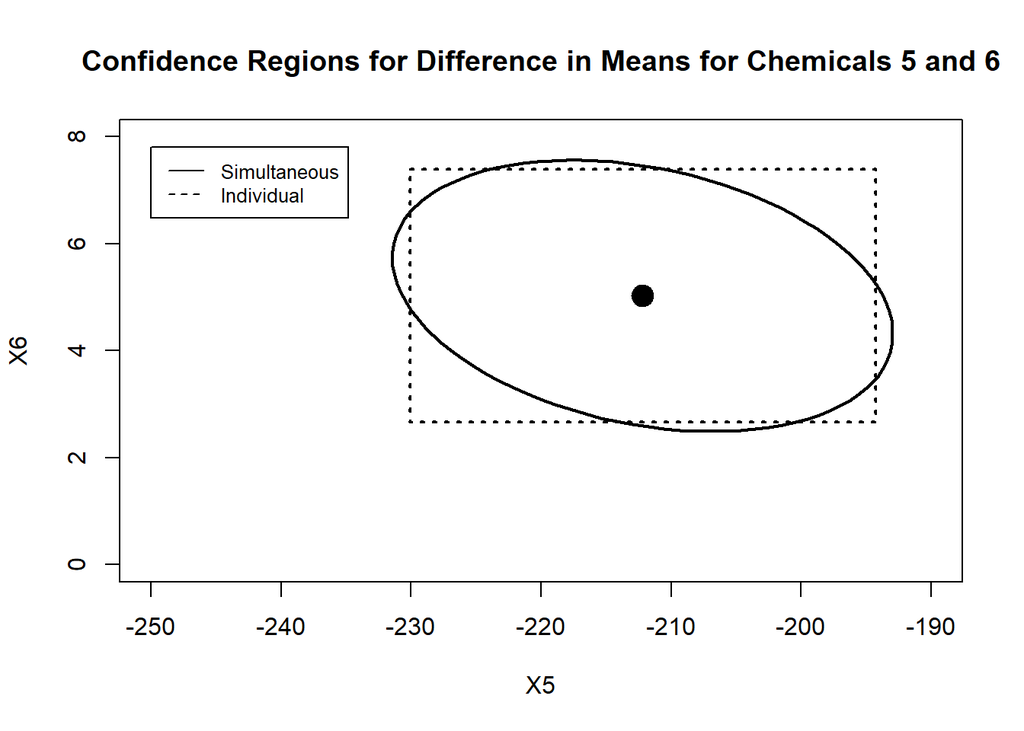